# Lab 2: R Basics and Data Types

# 1 Create a script

To start, open the GEOG316 R project that you created in the last lab. You can do this either my opening RStudio and then going to:

> **File > Open Project**

or by simply double-clicking on the .Rproj file in your file explorer. Now you want to create an R script for Lab 2. Remember how to do that? Instead of using the **File** menu, you can also click on the icon that looks like a white sheet of paper with a green plus sign on it (Fig. 1.1). Make sure to save your script as LastName_Lab2.

[figure not shown]

Figure 1.1: Create a new script

# 2 Basic math

You can do many, many things with R, including use it as a calculator! You would be hard pressed to find a mathematical calculation that you could not do in R. Let’s look at the basics. For this lab you will be typing code in your script, running it, and then typing the result of the expression as a comment. All of the code that I want you to type, run, and report the results for will be in the grey boxes. For instance, if you see this:

```r
1 + 1
```

You would write this in your script:

```r
1 + 1
# 2
```

You can copy and paste the results into your script rather than typing them. However, I would warn against copying and pasting code out of this document and into R. You won’t learn nearly as much if you aren’t writing the code yourself.

## 2.1 Operators

Here are some of the basic operators that we will use in class.

| Operation | Operator |
| --- | --- |
| Addition | $+$ |
| Subtraction | $-$ |
| Multiplication | $*$ |
| Division | / |
| Exponentiation | ^ |

Give some of them a try!

```r
1 + 5

97 - 105

23 * 6

12 / 4

2 ^ 8
```

## 2.2 Order of operations

Remember PEMDAS? R sure does! R respects the mathematical order of operations. It’s always good to include parenthesis to keep your code organized and to make sure that you are calculating what you think you are. Data quality, right?

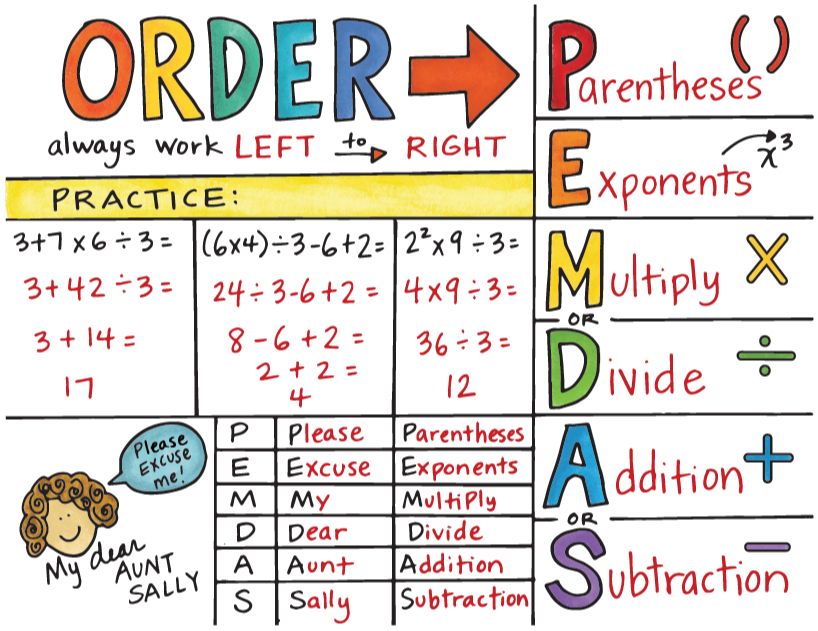

Figure 2.1: Order of operations, image credit: (https://scottiesinfifth.weebly.com/order-of-operations.html)

Try these out.

```r
4 * 6 + 2

(4 * 6) + 2

4 * (6 + 2)

4 ^ 2 + 6

(4 + 6) ^ 2

4 + 6 ^ 2

4 + 6 / 2

(4 + 6) / 2
```

## 2.3 Mathematical functions

Every operation in R is done with a function, which **returns** a result. Some of them look different, like the operators above. But actually, what the **+** operator is really doing is calling the function **sum()**. All functions take **arguments** which are separated by commas.

```r
4 + 6

sum(4, 6)
```

The arguments are the way you tell R what you want to do the function to and the specific manner that you want it to do it. In a lot of functions you don’t need to specify the way it’s done but really what you are doing is accepting the default values. For instance, in the **sum()** function, you can specify whether or not missing values should be removed from the calculation. More on missing values later. Here are some basic mathematical functions that we may use in the lab:

| Function | What it does |
| --- | --- |
| sum(x, y, z …) | Returns the sum of x, y, and z |
| round(x, digits = y) | Returns x rounded to y digits |
| abs(x) | Returns the absolute value of x |
| sqrt(x) | Returns the square root of x |
| log(x, base = y) | Returns the logarithm of x with base y; if base is not specified, returns the natural logarithm |
| exp(x) | Returns the exponential of x |
| factorial(x) | Returns the factorial of x (x!) |
| choose(x,y) | Returns the number of possible combinations when drawing y elements at a time from x possibilities |
| sin(x) | Returns the sine of x (in radians) |
| cos(x) | Returns the cosine of x (in radians) |
| tan(x) | Returns the tangent of x (in radians) |

Now you try!

```r
round(pi, 6)

round(pi, 3)

sqrt(100)

100 ^ 0.5

abs(-10)

abs(10)

log(64, base = 2)

2 ^ 6

log(64, base = 8)

8 ^ 2

log(64)

exp(1)  # This is Euler's number!

exp(2)

log(7.389056)

factorial(4)

choose(5, 5)

choose(5, 4)

choose(5, 3)

choose(5, 2)

choose(5, 1)

choose(5, 0)

cos(pi)
```

**[Euler’s number](https://www.popularmechanics.com/science/math/a24383/mathematical-constant-e/)**

# 3 Variables

A variable in R (and in programming in general) is a way to store and organize information. You **assign** a value to a name, and R remembers it for you! Variables are flexible because they can store any kind of value you want, you can use them repeatedly, and you can also reassign them to values, for instance if you are **iterating** (repeating) a process like in a **for loop**. Don’t worry if that doesn’t quite make sense yet. It will by the end of the semester!

To assign a variable in R you use a **leftward arrow (<-)**. You can also use an **equals sign (=)** but this is considered poor coding form. Let’s not be that way! What you want to name the variable goes to the left of the arrow and the value goes to the right. The value that you assign to the variable can be just about anything! You can check what the value of a variable is by **printing** it. You just type the name of the variable in the console, or run it in your script, and R will print out the value. You can remove a variable from your environment with **rm()**.

```r
x <- 10

x

var <- 10 + 10

var

var <- sum(10, 1)

var

rm(var)
```

Notice that when we assign a new value to a variable, it overwrites the old value. Variable names should be short and information. In addition, the only characters that you can use are letters, numbers, dots, and underscores and the variable name needs to start with a letter.

Table 3.1: Variable names

| Good | Bad |
| --- | --- |
| var.1 | 1.var |
| dog_cost | dog$ |
| class.num | _class_num |

# 4 Data types

So what are those different kinds of things you can assign to variables anyways? The basic data structure in R is called a **vector**. A vector is simply a sequence of elements or components. You know how to create a vector of one—you simple type a value or assign it to a variable. To create a vector with more than one element you use the **c()** function. The **c** stands for **combine** and you will see that one a lot.

```r
x <- 1

x

y <- c(1, 2, 3)

y
```

There are two types of vectors: **atomic vectors** and **lists**. Every vector is defined by two properties: its **type** and its **length**. You can check the type of a vector by using the function **typeof()** and its length with the function **length()**. That’s not too hard, right?

There are four types of atomic vectors: **logical**, **integer**, **double**, and **character**. You may see these referred to as data types. Atomic vectors only contain one type of data while lists can contain multiple types of data. We will go over lists in the next lab. A vector can contain one element or it may contain many. You can check to see what type a vector is with **class()**. Let’s go over them in more detail.

## 4.1 Logical

Logical vectors are the simplest type. They are usually made by comparing things. Are these to things equal? The answer would either be yes or no. In R that’s TRUE or FALSE. You can check to see if an object is a logical vector by using the function **is.logical()**.

Table 4.1: Comparison operators

| Operation | Operator |
| --- | --- |
| Greater than | > |
| Greater than or equal to | >= |
| Less than | < |
| Less than or equal to | <= |
| Equal to | == |
| Not equal to | != |

```r
3 > 2

3 > 4

3 <= 4

3 <= 3

3 == 3

3 != 3

x <- 3 == 3

x

is.logical(x)

class(x)
```

## 4.2 Numeric

Together integer and double vectors are called **numeric vectors**. The only difference is that integers are whole numbers (-1, 0, 1, 2, 3), while doubles have decimals (-1.0, 0.1, 0.0000001). To specify that a number is an integer, you simply place a “L” after the number. You can check to see if an object is a numeric vector with the function **is.numeric()**. If you need to be more specific, there is also **is.integer()** and **is.double()**.

```r
typeof(1)

typeof(1L)

x <- 1L + 0.5

typeof(x)

y <- c(1, 3.5, 7)

typeof(y)

length(y)

sum(y)

is.numeric(y)

class(y)
```

## 4.3 Character

Character vectors are made up of **string** elements. As with the other vector types, a character vector may have one element (one string) or more than one element (more than one string). A string is a set of characters that come between quotation marks ("“) and represents text. Kinda like a word. You can also use single quotes (’‘) in R—you just have to make sure the closing quote matches the opening quote. So, "" or’’ but not”’. Strings represent nominal and ordinal data in statistical anaylsis. You can use **nchar()** to find the number of characters in a string. If you use **length()** the result is the number of strings in the character vector.

```r
var <- "Kansas"

var

typeof(var)

is.character(var)

var2 <- "University of Kansas"

var3 <- "Jayhawks"

nchar(var2)    # Do spaces count as characters?

length(var2)

var4 <- c(var2, var3)

nchar(var4)

length(var4)

class(var4)
```

There’s another kind of character vector that behaves like a numerical vector called a **factor**. There are numeric **levels** associated with each of the strings in the character vector. For instance, imagine that you administered a survey and want to analyze your results. You asked respondants to rank their level of satisfaction: satisfied, neutral, dissatisfied. To perform stastical analysis you need to **code your variables** (represent them with numbers). Factors do just that. This also helps with quality control because factor elements can take only values that are specified in the levels.

```r
# Note that the line breaks here don't matter to R.
# You could write this in one long line.
# It matters to us because it makes the code easier to read.

responses <- c("satisfied",
               "satisfied",
               "not satisfied",
               "neutral",
               "satisfied",
               "neutral",
               "stsfied")

satisfaction_levels <- c("not satisfied", "neutral", "satisfied")
```

The factor function looks like: factor(x, levels). Your data is x, in this case the responses, and levels is a character vector specifying the values that the data can take.

```r
satisfaction <- factor(responses, satisfaction_levels)

satisfaction
```

Notice how the value “stsfied” was turned into an NA (missing values are next!). This is because the string was not an acceptable level. This helps identify typos and other forms of improperly recorded data.

There’s one more thing that we can do. Since this is an **ordinal** variable, we specify the hierarchy of the levels. If the variable was **nominal** this doesn’t matter because there is no rank to the different values.

```r
satisfaction <- factor(responses, ordered = T, levels = satisfaction_levels)

satisfaction
```

## 4.4 Missing values

Finally! Missing values can occur for any number of reasons. Maybe in your survey, a respondant did not answer one of the questions. Maybe when you were typing in the responses you made a typo. Sometimes equipment malfunctions. Sometimes the power goes out. In R, this missing data is coded with an **NA**, which stands for **not available**. R can’t perform operations on NAs so in many functions, like sum(), you need to explicitley tell R to ignore them. In many cases you do this by adding the arguement **na.rm = TRUE** to the function. Sometimes you may come across **NaN** which stands for **not a number**. This is the result of impossible operations, like taking the square root of a negative number. **Inf** stands for infinity and **-Inf** stands for negative infinity.

```r
z <- c(1, 2, NA, 8, 3, NA, 3)

z

is.na(z)

sum(z)

sum(z, na.rm = T)

sqrt(-1)

1 / 0

-1 / 0
```

# 5 Working with vectors

We saw that you can create a vector by using **c()** but there are other ways too. By using a colon, you can create a sequence of numbers.

```r
1:10
```

There are also functions, like **rep()** and **seq()**. Can you guess what those do?

```r
rep(1, length.out = 10)

seq(from = 1, to = 2, by = 0.1)
```

You can use operators on numeric vectors. The oepration will be applied to each element in the vector. You can even use the comparison operators. If you want to know if at least one element meets a criteria you can use **any()** and if you want to know if every element meets a criteria you can use **all()**.

```r
x <- seq(from = 1, to = 5, by = 1)

x

x * 2

x * x

x < 3

any(x < 3)

all(x < 3)
```

You can also use operators with more than one vector. Say that you need to add students’ extra credit points to their test grades.

```r
test.grades <- c(90, 95, 80, 72, 83)

xtra.credit <- c(5, 5, 3, 5, 2)

test.grades + xtra.credit
```

Performing operations on two vectors that have different lengths is problematic. The shorter vector gets **recycled**, which means its elements are repeated. If the length of the longer vector is not a multiple of the length of the shorter vector, R will give you a warning message.

```r
x <- (1:5)

x

y <- seq(from = 1, to = 4, by = 0.5)

y

x + y
```

Mathematical functions can be applied to vectors too. We’ve already looked at **sum()**. **min()**, which returns the minimum value, and **max()**, which returns the maximum value can be very useful as well.

```r
max(test.grades)

min(test.grades)

sum(xtra.credit)
```

You can also access a subset of the elements of a vector by using the **indices** of the elements you are interested in. Indices is the plural of index. The index is the number of the slot the element occupies, e.g. the third element in a vector. You place the index in **square brackets** [] after the name of your variable.

```r
test.grades[1]

test.grades[1:3]

test.grades[c(1, 3, 5)]
```

# 6 Exercises

1. Create a new R vector called **grades** that contains the following values: 95, 75, 68, 77, 75, 77, 75, 93, 87, 95.
2. Create a variable **n** that represents the number of elements contained within the grades vector.
3. Display only the first five elements of the grades vector.
4. Display only the last five elements of the grades vector.
5. What is the minimum grade?
6. What is the maximum?
7. Subtract each element of the grades vector by the minimum value.
8. Perform the following operations on the grades vector:
   $$\sum_{i = 1}^{n}x_i$$
   $$\sum_{i = 2}^{n}x_i$$
   $$\sum_{i = 1}^{n - 1}x_i$$
   $$\frac{\sum_{i = 1}^{n}x_i}{n}$$